# Raport PD3

Norbert Trojan

## Cel:

Celem jest porównanie jak sprawdzą się dwie metody przezentacji danych. Przy pomocy wykresu kołowego 3D oraz przy pokmocy wykresu słukowego 2D. 15 ankietowanych miła za zadanie odczytać dane z wykresu, porównać, która wartość jest większa oraz ilokrotnie przewysza drugą. Następnie mieli odpowiedzieć jaką pewność mają, że ich interpretacja wykresu jest poprawna.

Link do ankiety: https://docs.google.com/forms/d/e/1FAIpQLSekweWcIczLB2YFTD9FJ6DtoOCU1zGJQZrmFlJtXLvT3HcXAQ/viewform?usp=sf_link

## Wykresy:

### Wykres 1a:

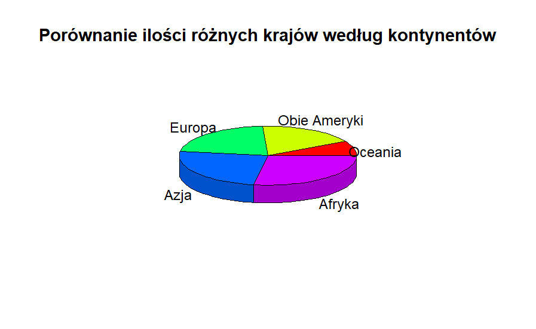

### Wykres 1b:

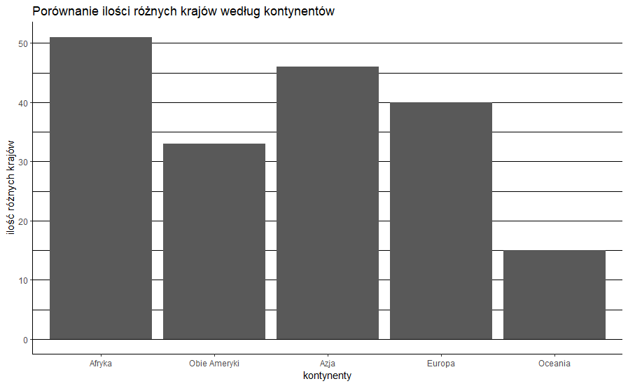

### Pytania i odpowiedzi:

Na którym kontynencie jest więcej krajów?

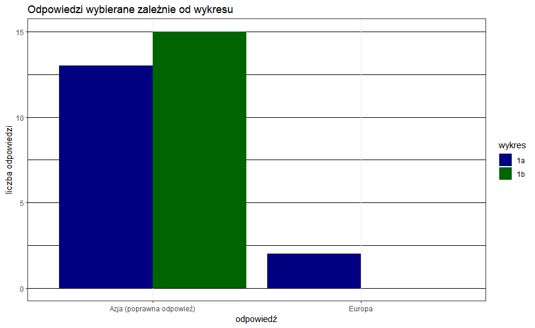

Ile razy jest więcej krajów w Afryce niż w Oceani?

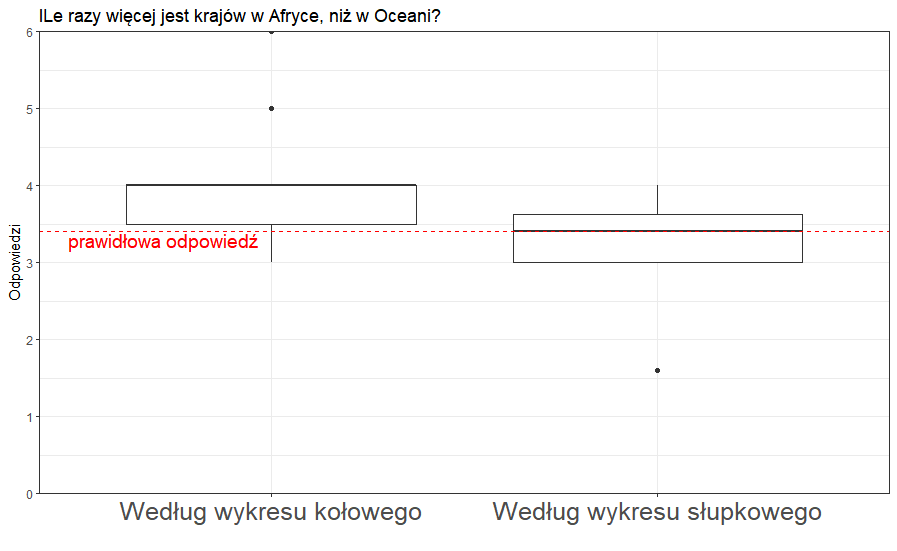

Jak bardzo jesteś pewien/pewna swojej odpowiedzi?

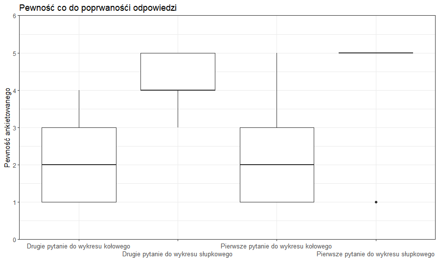

### Wykres 2a:

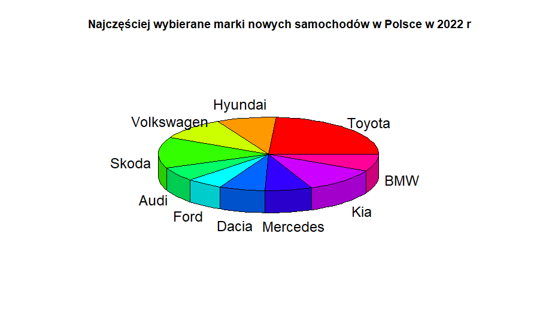

### Wykres 2b:

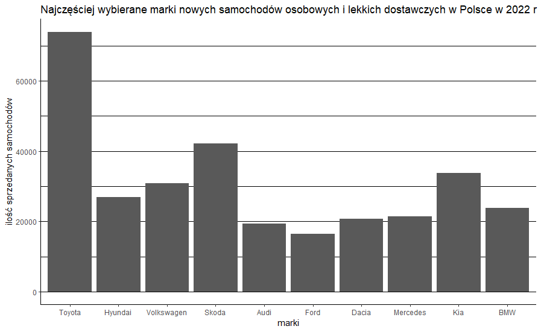

### Pytania i odpowiedzi:

Która marka była wybierana częściej?

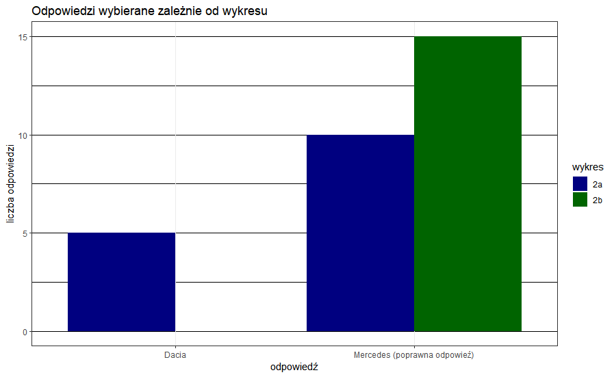

Ile razy częściej wybierana jest Skoda, niż Ford?

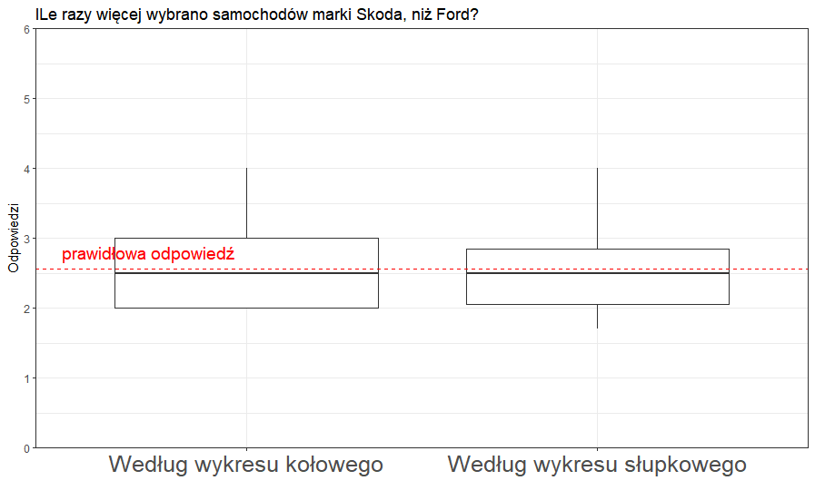

Jak bardzo jesteś pewien/pewna swojej odpowiedzi?

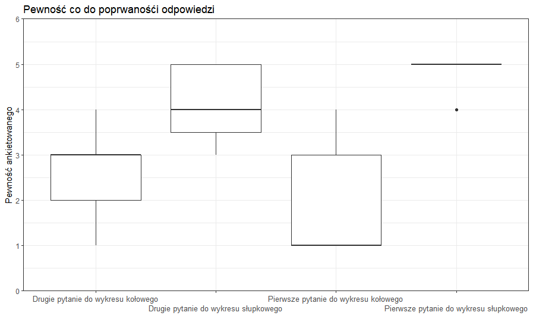

## Wnioski:

Wyniki pokazują, żę przy prostym porównaniu wartości wykres słupkowy wypada znacznie lepiej. Przdewszystkim ankietowani zawsze podawali prawidłową odpowiedź i byli jej pewni, przy wykresie kołowym 3D zdarzały się bładne odpowiedzi i odpowiadający byli znacznie mniej przekonani co do poprawności. Przy porównywaniu krotności wartości wykres słupkowy, również sprawdził się lepiej. Ankietowani podawli delikatnie lepsze odpowiedzi i byli znacznie pewniejsi co do ich poprawności.